# DS202 Homework 5

Aaron Jencks

4/10/2020

## Liquor Sales in Iowa

This dataset https://data.iowa.gov/Sales-Distribution/2019-Iowa-Liquor-Sales/38x4-vs5h contains the spirits purchase information of Iowa Class “E” liquor licensees by product and date of purchase for 2019. The dataset can be used to analyze total spirits sales in Iowa of individual products at the store level.

**Submission instructions**: Create a folder named `ds202_hw5`, and name the RMarkDown file including your solutions `hw5.Rmd` under this folder. For the submission, create a GitHub repository named `ds202_hw5` under your GitHub account, and push both `hw5.Rmd` and the knitted `hw5.html` before the deadline. I will assume you use the same GitHub username as for your HW4 submission. The latest version of your homework appearing on GitHub before the deadline is graded. *It is crucial to follow the exact folder structure and file names*, so that your homework can be reproduced and graded by an automated script. This homework is **due on April 10** by 11:59 pm.

1. The complete dataset is too large. Download and import the alcohol sales data for Ames only:
1. Go to https://data.iowa.gov/Sales-Distribution/2019-Iowa-Liquor-Sales/38x4-vs5h
2. Click Filter – Filter – Go advanced now
3. Add a New Filter Condition: City is Ames.
4. Export – CSV – Download
5. Use `readr::read_csv` to import.

````
```r
liquor = readr::read_csv('./2019_Iowa_Liquor_Sales.csv')
```

```
## Parsed with column specification:
## cols(
##   .default = col_double(),
##   `Invoice/Item Number` = col_character(),
##   Date = col_character(),
##   `Store Name` = col_character(),
##   Address = col_character(),
##   City = col_character(),
##   `Store Location` = col_character(),
##   County = col_character(),
##   `Category Name` = col_character(),
##   `Vendor Number` = col_character(),
##   `Vendor Name` = col_character(),
##   `Item Description` = col_character()
## )
```

```
## See spec(...) for full column specifications.
```

```r
# str(liquor)
```
````

2. Data cleaning:
1. extract geographic latitude and longitude from the variable `Store Location`
2. make sure the variables are in the correct type, by converting incorrect variable types.
3. extract year, month and day from the variable `Date` as separate columns.

````
```r
names(liquor) = str_replace_all(names(liquor), c(" " = ".", "," = "", "/" = ".", "\\(" = "", "\\)" = ""))

# Cleans up the duplicate categories
liquor = liquor %>% mutate(Category.Name = str_replace_all(Category.Name, c(
    "Temporary &  Specialty Packages" = "Temporary & Specialty Packages",
    "Vodkas" = "Vodka",
    "Spirit Specialty" = "Spirits Specialty",
    "Liqueurs" = "Liqueur",
    "/RTD" = "/ RTD")))


# Part b.
liquor = liquor %>%
    mutate(Date = mdy(Date), str_date = Date, doy = yday(Date),
        Category.Name = factor(Category.Name, sort(unique(Category.Name))),
        Vendor.Name = factor(Vendor.Name, sort(unique(Vendor.Name))),
        Item.Description = factor(Item.Description, sort(unique(Item.Description))),
        Pack = factor(Pack, sort(unique(Pack))),
        Vendor.Number = as.numeric(Vendor.Number))

# Part c.
liquor = liquor %>%
    separate(Date, c("Year", "Month", "Day"), "-") %>%
    mutate(Month = as.numeric(Month), Day = as.numeric(Day), Year = as.numeric(Year))

# Part a.
loc_data =  liquor %>%
    filter(!is.na(Store.Location)) %>%
    mutate(Lat.Long = str_extract_all(Store.Location, "-?[:digit:]+\\.?[:digit:]*")) %>%
    separate(Lat.Long, c("Lat", "Long"), ",") %>%
    mutate(Lat = as.numeric(str_extract(Lat, "-?[:digit:]+\\.?[:digit:]*")),
        Long = as.numeric(str_extract(Long, "-?[:digit:]+\\.?[:digit:]*")))

# str(loc_data)
```
````

3. First overview:
1. Plot a scatterplot of lat and long of store locations.
2. Provide a visual breakdown of the liquor category (by `Category Name`). Include volume sold in the breakdown.

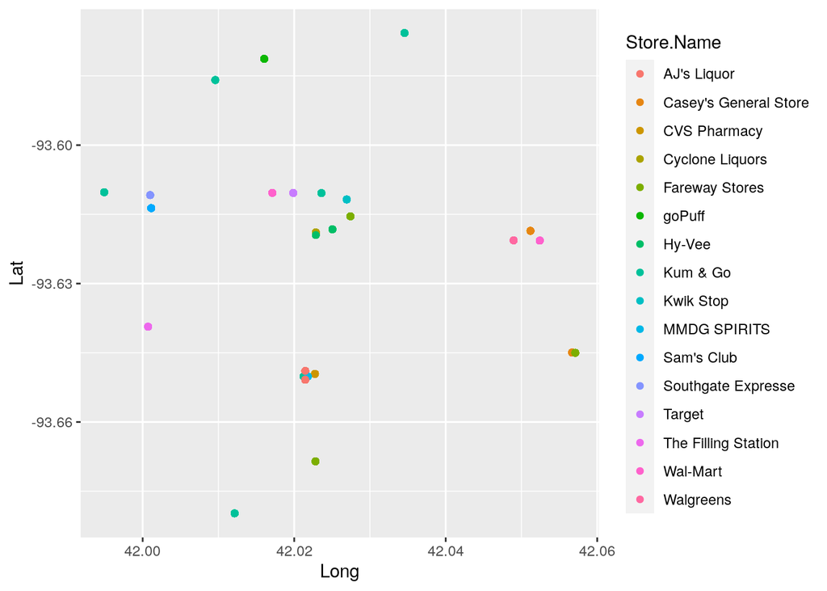

```r
# Part a.
# Cleans up the store names a bit
loc_data = loc_data %>%
    mutate(Store.Name = str_replace_all(Store.Name, c(
        "AJ'S LIQUOR.+" = "AJ's Liquor", "AJ's Liquor.+" = "AJ's Liquor",
        "Casey's General Store.+" = "Casey's General Store",
        "Fareway Stores.+" = "Fareway Stores",
        "Kum & Go.+" = "Kum & Go",
        "Hy-Vee.+" = "Hy-Vee",
        "Wal-Mart.+" = "Wal-Mart",
        "CVS Pharmacy.+" = "CVS Pharmacy",
        "Kwik Stop.+" = "Kwik Stop",
        "Target Store.+" = "Target",
        " / Ames" = "",
        " - Ames" = "",
        "#[:digit:]+" = "",
        "[:digit:]+" = "")))

ggplot(loc_data, aes(x = Long, y = Lat, color=Store.Name)) + geom_point()
```

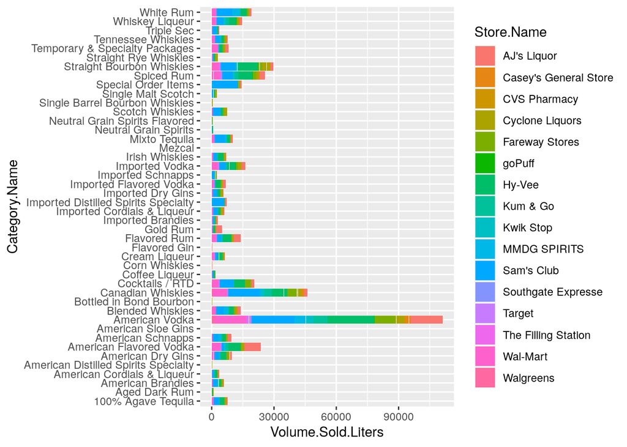

```r
# Part b.
loc_data %>% filter(!is.na(Category.Name)) %>% ggplot(aes(x = Category.Name, y = Volume.Sold.Liters, fill=Store.Name)) + geom_bar(stat="identity") + coord_flip()
```

4. Find the daily sales liquor sales in Ames in 2019. Summarize the number of sales, volume of liquor sold, and amount of money spent.

```r
sales_df = liquor %>% group_by(doy)  # %>% filter(!is.na(Sale.Dollars))
sales_data = sales_df %>% summarize(sales = n(), gross = sum(Sale.Dollars), volume = sum(Volume.Sold.Liters))
str(sales_data)
```

```
## tibble [157 × 4] (S3: tbl_df/tbl/data.frame)
##  $ doy   : num [1:157] 3 4 9 10 11 16 18 24 25 30 ...
##  $ sales : int [1:157] 957 143 944 2 177 912 62 1221 253 1082 ...
##  $ gross : num [1:157] 112009 16766 99703 1457 16481 ...
##  $ volume: num [1:157] 6816 1256 6732 135 1205 ...
```

5. Plot volume sold by day (use a scatterplot of volume by day and facet by month). Discover trends with the help of `geom_smooth`. Describe any patterns.

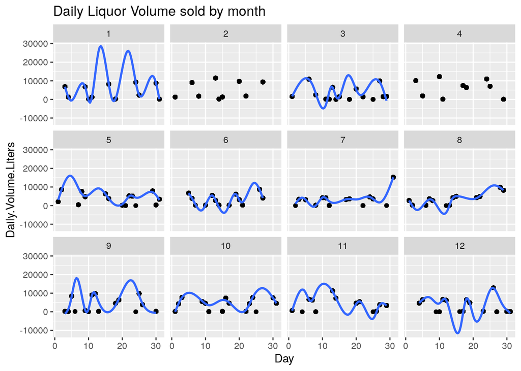

```r
sales_df = sales_df %>% group_by(doy) %>% mutate(Daily.Volume.Liters = sum(Volume.Sold.Liters)) %>% ungroup()
# str(sales_df)
ggplot(sales_df, aes(x = Day, y = Daily.Volume.Liters)) + geom_point() + facet_wrap(~Month) + geom_smooth() + labs(title = "Daily Liquor Volume sold by month")
```

6. Find the dates for ISU football home games in Fall 2019. Can you see a pattern?

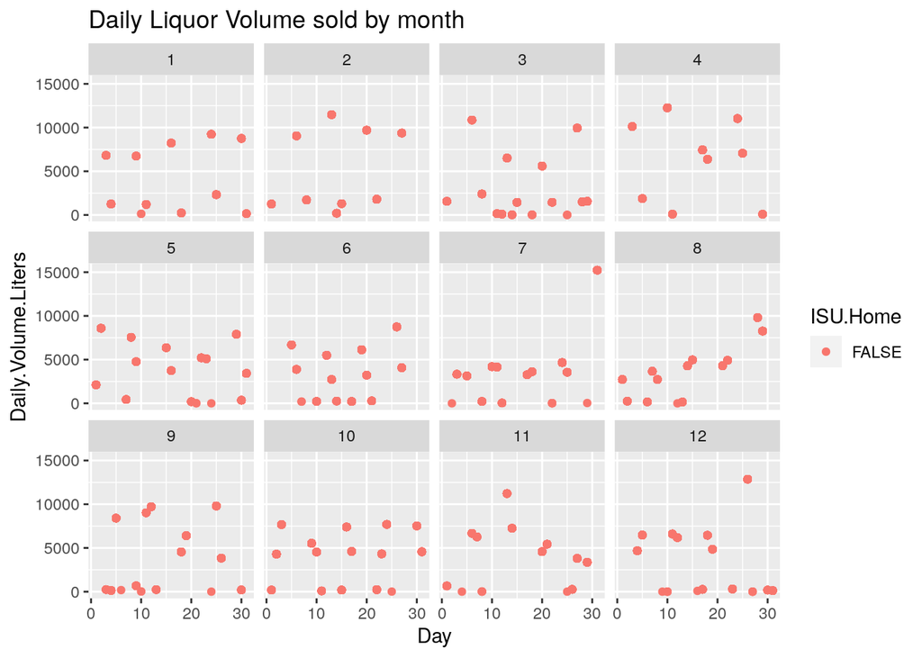

```r
game_dates = mdy(c("8/31/2019", "9/14/2019", "9/21/2019",
    "10/5/2019", "10/26/2019",
    "11/16/2019", "11/23/2019", "11/30/2019")) %>% str_replace_all(c("/" = "-"))
# str(game_dates)
sales_df = sales_df %>% mutate(ISU.Home = str_date %in% game_dates)
ggplot(sales_df, aes(x = Day, y = Daily.Volume.Liters, color=ISU.Home)) + geom_point() + facet_wrap(~Month) + labs(title = "Daily Liquor Volume sold by month")
```

I’m gonna be honest with you, I don’t really see the pattern here other than that all of the liquor stores are closed on game days and that more liquor is sold during football season, than in the summer.

Note: your submission is supposed to be fully reproducible, i.e. the TA and I will ‘knit’ your submission in RStudio.